# Assignment 1: Data Preprocessing and EDA for E‑Commerce Orders

This notebook is your working template for **Assignment 1**.

You will:

- Load **four tables** (`orders`, `order_items`, `order_shipping`, `payments`).
- Join them into a single order-level dataset.
- Clean and transform the data.
- Perform basic EDA and visualization.

Work **top-to-bottom**. Complete each sub-part in the order they appear before proceeding.

## Submitted by

Group number on Canvas: Group 6

| Student ID (AxxxxxxxZ) | NUSNet ID (exxxxxxx) | Name (as it appears on Canvas) |
| --- | --- | --- |
| A0314564E | E1504033 | Wang Siqin |
| A0314571J | E1504040 | Li Ran |
| A0146980W | E0011258 | Liu Zhenkun |

## Setup

Run the cell below to import the required Python packages.

```python
# Import the required Python packages for data processing and visualisation
import numpy as np
import pandas as pd
import matplotlib.pyplot as plt
import sklearn
import seaborn as sns

# Set a visually appealing plotting style
plt.style.use('seaborn-v0_8')
```

## Part 1: Data Preprocessing (10 marks)

### 1.1 Data Loading & Joining (4 marks)

We first load each table, inspect it, and then join them into a single DataFrame.

#### Load the CSV files

**Task:**

- Dowload the four CSV files from canvas and upload them under the 'files' tab for this colab instance
- Load the four CSV files using `pd.read_csv()` into:
  - `df_orders`
  - `df_order_items`
  - `df_shipping`
  - `df_payments`

Update the filenames/paths if necessary.

```python
# Load the CSV files
df_orders = pd.read_csv('/content/orders.csv')
df_order_items = pd.read_csv('/content/order_items.csv')
df_shipping = pd.read_csv('/content/order_shipping.csv')
df_payments = pd.read_csv('/content/payments.csv')
```

#### Inspect each table

**Task:**

- For **each** DataFrame, display:
  - `head()` (first 5 rows)
  - `shape` (rows, columns)

This helps you understand the raw structure before joining.

```python
# Inspect the DataFrames
df_orders.head()
```

|  | order_id | order_status | order_purchase_hour | order_purchase_dayofweek | order_purchase_month | order_total_value |
| --- | --- | --- | --- | --- | --- | --- |
| 0 | sdv-id-whzjUX | shipped | 10 | 4 | 4 | 744.312535 |
| 1 | sdv-id-gqShVM | delivered | 19 | 2 | 4 | 1030.521912 |
| 2 | sdv-id-vtaqcY | delivered | 18 | 4 | 8 | 28.472994 |
| 3 | sdv-id-xkqwdo | invoiced | 23 | 1 | 8 | 143.914263 |
| 4 | sdv-id-sGyHvQ | delivered | 19 | 0 | 2 | 16.944537 |

```python
df_orders.shape
```

```
(100000, 6)
```

```python
df_order_items.head()
```

|  | order_id | num_items | num_unique_products | num_unique_sellers | total_item_price | avg_item_price | total_freight_value | top_product_category |
| --- | --- | --- | --- | --- | --- | --- | --- | --- |
| 0 | sdv-id-whzjUX | 1 | 1 | 1 | 352.420029 | 369.966521 | 68.790159 | construction_tools_construction |
| 1 | sdv-id-gqShVM | 1 | 1 | 1 | 1580.187928 | 1089.284136 | 84.603289 | auto |
| 2 | sdv-id-vtaqcY | 1 | 1 | 1 | 45.969263 | 36.969754 | 24.022637 | furniture_decor |
| 3 | sdv-id-xkqwdo | 1 | 1 | 1 | 146.023435 | 126.755360 | 16.945349 | consoles_games |
| 4 | sdv-id-sGyHvQ | 1 | 1 | 1 | 30.525812 | 22.797409 | 17.785846 | air_conditioning |

```python
df_order_items.shape
```

```
(100000, 8)
```

```python
df_shipping.head()
```

|  | order_id | customer_state |
| --- | --- | --- |
| 0 | sdv-id-whzjUX | Massachusetts |
| 1 | sdv-id-gqShVM | Ohio |
| 2 | sdv-id-vtaqcY | Wisconsin |
| 3 | sdv-id-xkqwdo | Michigan |
| 4 | sdv-id-sGyHvQ | Nevada |

```python
df_shipping.shape
```

```
(100000, 2)
```

```python
df_payments.head()
```

|  | order_id | payment_type |
| --- | --- | --- |
| 0 | sdv-id-whzjUX | voucher |
| 1 | sdv-id-gqShVM | voucher |
| 2 | sdv-id-vtaqcY | voucher |
| 3 | sdv-id-xkqwdo | credit_card |
| 4 | sdv-id-sGyHvQ | credit_card |

```python
df_payments.shape
```

```
(100000, 2)
```

#### Join the tables on `order_id` to create a single order-level DataFrame

**Task:**

- Perform **inner joins** on `order_id` so that only orders present in **all** tables remain.
- Join order tables in this order:
  1. `df_orders` with `df_order_items`
  2. result with `df_shipping`
  3. result with `df_payments`
- Store the final DataFrame as `df_orders_full`.
- Display `head()` and `shape` for `df_orders_full`.

```python
# Join the tables sequentially
df_final = pd.merge(df_orders, df_order_items, on='order_id', how = 'inner')
df_final = pd.merge(df_final, df_shipping, on='order_id', how = 'inner')
df_final = pd.merge(df_final, df_payments, on='order_id', how = 'inner')
df_orders_full = df_final
df_orders_full.head()
```

|  | order_id | order_status | order_purchase_hour | order_purchase_dayofweek | order_purchase_month | order_total_value | num_items | num_unique_products | num_unique_sellers | total_item_price | avg_item_price | total_freight_value | top_product_category | customer_state | payment_type |
| --- | --- | --- | --- | --- | --- | --- | --- | --- | --- | --- | --- | --- | --- | --- | --- |
| 0 | sdv-id-whzjUX | shipped | 10 | 4 | 4 | 744.312535 | 1 | 1 | 1 | 352.420029 | 369.966521 | 68.790159 | construction_tools_construction | Massachusetts | voucher |
| 1 | sdv-id-gqShVM | delivered | 19 | 2 | 4 | 1030.521912 | 1 | 1 | 1 | 1580.187928 | 1089.284136 | 84.603289 | auto | Ohio | voucher |
| 2 | sdv-id-vtaqcY | delivered | 18 | 4 | 8 | 28.472994 | 1 | 1 | 1 | 45.969263 | 36.969754 | 24.022637 | furniture_decor | Wisconsin | voucher |
| 3 | sdv-id-xkqwdo | invoiced | 23 | 1 | 8 | 143.914263 | 1 | 1 | 1 | 146.023435 | 126.755360 | 16.945349 | consoles_games | Michigan | credit_card |
| 4 | sdv-id-sGyHvQ | delivered | 19 | 0 | 2 | 16.944537 | 1 | 1 | 1 | 30.525812 | 22.797409 | 17.785846 | air_conditioning | Nevada | credit_card |

```python
df_orders_full.shape
```

```
(100000, 15)
```

### 1.1 Data Loading and Joining Summary

We loaded four separate relational tables ('orders', 'order_item', 'shipping', 'payments') and merged them sequentially using an inner join on the unique 'order_id'. By linking these relational tables, we created a comprehensive view of the unified dataset of the transaction records, functioning as the foundation for analyzing the end to end customer journey.

### 1.2 Data Cleaning (3 marks)

We now clean `df_orders_full` so it is ready for analysis.

#### Handle missing values

**Task:**

- For **numerical** columns: replace missing values with the **median** of that column.
- For **categorical** columns: replace missing values with the **mode** (most frequent value).
- Drop any rows where `order_id` or `payment_type` is missing (if any remain)

Work directly on `df_orders_full`.

```python
# Separate columns by data type for appropriate data imputation
numerical_cols = df_orders_full.select_dtypes(include=['number']).columns
categorical_cols = df_orders_full.select_dtypes(include=['object']).columns

# Fill missing numerical values with the median
df_orders_full[numerical_cols] = df_orders_full[numerical_cols].fillna(df_orders_full[numerical_cols].median())

# Fill missing categorical values with the mode (most frequent value)
for col in categorical_cols:
    col_mode = df_orders_full[col].mode()
    if not df_orders_full[col].mode().empty:
        df_orders_full[col] = df_orders_full[col].fillna(col_mode[0])

# Drop records lacking tracking IDs as they cannot be tied to a customer
df_orders_full.dropna(subset=['order_id', 'payment_type'], inplace=True)
```

```python
df_orders_full.shape
```

[output not shown]

#### Remove clearly invalid numeric records

**Task:**

- Remove rows where:
  - `num_items` ≤ 0, or
  - `order_total_value` ≤ 0, or
  - `total_item_price` < 0, or
  - `total_freight_value` < 0.

```python
# Filter out logically impossible entries

df_orders_full = df_orders_full[
    (df_orders_full['num_items'] > 0) &
    (df_orders_full['order_total_value'] > 0) &
    (df_orders_full['total_item_price'] >= 0) &
    (df_orders_full['total_freight_value'] >= 0)]
```

#### Check cleanliness and key uniqueness

**Task:**

- Confirm there are **no null values** in `df_orders_full`.
- Check that `order_id` is unique (one row per order).

```python
# Verify the final cleaned shape and uniqueness
print(f"Any null values remaining: {df_orders_full.isnull().values.any()}")
print(f"Are all order_id values unique: {df_orders_full['order_id'].is_unique}")
```

```
Any null values remaining: False
Are all order_id values unique: True
```

```python
df_orders_full.shape
```

```
(46287, 15)
```

### 1.2 Data Cleaning Summary

In the process of data clearning, we imputed missing numerical values with the median and missing categorical values with mode. We also performed rows dropping for the rows missing critical key identifies and performed filtering out for these logically invalid numeric records. This is because "dirty" data leads to incorrect business decisions. Missing categories skew product trend analysis, and negative prices heavily distort revenue and profitability analysis. Replacing missing values and filtering out invalid records guarantees that strategic decisions and financial insight are based on reliable, high-quality data.

### 1.3 Data Transformation (3 marks)

Next, we perform sanity checks and create new features that will be useful later.

#### Sanity checks on counts and values

**Task:**

- Keep only rows where both:
  - `num_items` ≥ `num_unique_products`,
  - `order_total_value` ≥ `total_item_price + total_freight_value`

```python
# Sanity Logic Checks: total items must be greater or equal to unique products; total order value should cover the price of items plus shipping freight
df_orders_full = df_orders_full[
    (df_orders_full['num_items'] >= df_orders_full['num_unique_products']) &
    (df_orders_full['order_total_value'] >= (df_orders_full['total_item_price'] + df_orders_full['total_freight_value']))]

df_orders_full.shape
```

```
(46287, 15)
```

#### Create `order_value_per_item`

**Task:**

- Create a new column `order_value_per_item` defined as `total_item_price / num_items`.

```python
# Calculate average value per item for the order
df_orders_full['order_value_per_item'] = df_orders_full['total_item_price'] / df_orders_full['num_items']
```

```python
df_orders_full.shape
```

```
(46287, 16)
```

#### Create `order_size_category`

**Task:**

- Create a new categorical column `order_size_category` with values:
  - "Small" if `num_items` ≤ 2
  - "Medium" if `num_items` ≤ 5
  - "Large" if `num_items` > 5

```python
# Group orders into analyzable segements: small, medium, large
df_orders_full['order_size_category'] = pd.cut(df_orders_full['num_items'], bins = [0, 2, 5, np.inf], labels = ['Small', 'Medium', 'Large'])
```

#### Final transformation check

**Task:**

- Confirm there are no null values in `df_orders_full`.
- Display:
  - `head()`
  - `shape`
  - `info()`

```python
# Display final transformation summary
df_orders_full.head()
```

|  | order_id | order_status | order_purchase_hour | order_purchase_dayofweek | order_purchase_month | order_total_value | num_items | num_unique_products | num_unique_sellers | total_item_price | avg_item_price | total_freight_value | top_product_category | customer_state | payment_type | order_value_per_item | order_size_category |
| --- | --- | --- | --- | --- | --- | --- | --- | --- | --- | --- | --- | --- | --- | --- | --- | --- | --- |
| 0 | sdv-id-whzjUX | shipped | 10 | 4 | 4 | 744.312535 | 1 | 1 | 1 | 352.420029 | 369.966521 | 68.790159 | construction_tools_construction | Massachusetts | voucher | 352.420029 | Small |
| 5 | sdv-id-dbopoJ | delivered | 19 | 2 | 3 | 1556.667902 | 1 | 1 | 1 | 289.242639 | 1354.621410 | 15.394619 | health_beauty | Vermont | credit_card | 289.242639 | Small |
| 8 | sdv-id-FSEOvM | delivered | 15 | 4 | 8 | 62.060506 | 1 | 1 | 1 | 26.893468 | 48.485654 | 18.751282 | luggage_accessories | South Carolina | debit_card | 26.893468 | Small |
| 12 | sdv-id-bQcBUR | delivered | 21 | 0 | 8 | 73.873470 | 1 | 1 | 1 | 37.790896 | 75.704909 | 8.670875 | computers_accessories | Kentucky | credit_card | 37.790896 | Small |
| 14 | sdv-id-MPxIXB | delivered | 13 | 5 | 5 | 361.961537 | 3 | 3 | 3 | 169.528323 | 50.132979 | 34.731146 | pet_shop | Missouri | voucher | 56.509441 | Medium |

```python
df_orders_full.shape
```

```
(46287, 17)
```

```python
df_orders_full.info()
```

```
<class 'pandas.core.frame.DataFrame'>
Index: 46287 entries, 0 to 99997
Data columns (total 17 columns):
 #   Column                    Non-Null Count  Dtype
---  ------                    --------------  -----
 0   order_id                  46287 non-null  object
 1   order_status              46287 non-null  object
 2   order_purchase_hour       46287 non-null  int64
 3   order_purchase_dayofweek  46287 non-null  int64
 4   order_purchase_month      46287 non-null  int64
 5   order_total_value         46287 non-null  float64
 6   num_items                 46287 non-null  int64
 7   num_unique_products       46287 non-null  int64
 8   num_unique_sellers        46287 non-null  int64
 9   total_item_price          46287 non-null  float64
 10  avg_item_price            46287 non-null  float64
 11  total_freight_value       46287 non-null  float64
 12  top_product_category      46287 non-null  object
 13  customer_state            46287 non-null  object
 14  payment_type              46287 non-null  object
 15  order_value_per_item      46287 non-null  float64
 16  order_size_category       46287 non-null  category
dtypes: category(1), float64(5), int64(6), object(5)
memory usage: 6.0+ MB
```

### 1.3 Data Transformation Summary

We apllied sanity check ensuring the logic between aggregate and individual metrics hold up. And we engineered new features with including average cost of items and order size category by item count. Creating the `order_value_per_item` metric acts as a proxy for the price segment of the order. Transforming raw data into segmented categories allows for deeper behavioral analysis.

Furthermore, categorizing orders into "Small", "Medium", and "Large" sizes clusters customers by purchasing behavior. This clustering helps identify distinct order segments for targeted promotions and optimized fulfillment strategies.

### 1.4 Data Storage

We now save the cleaned, joined, and transformed dataset.

#### 1.4A Save cleaned dataset

**Task:**

- Save `df_orders_full` as `ecommerce_orders_cleaned.csv` (without the index).

```python
# Save the final dataset to a CSV file without the index
df_orders_full.to_csv('ecommerce_orders_cleaned.csv', index=False)
print('Successful!')
```

```
Successful!
```

### 1.4 Data Storage Summary

We saved the finalized DataFrame to a CSV, allowing future usage of ingesting accurate data for downstream dashboards without repeating the cleaning process.

## Part 2: EDA & Data Visualization (4 marks)

We now reload the cleaned dataset and explore it.

### 2.0 Load Transformed Dataset

#### 2.0 Reload CSV

**Task:**

- Load `ecommerce_orders_cleaned.csv` into `df_orders_cleaned`.
- Display `head()` and `shape`.

```python
# Reload the cleaned dataset
df_orders_cleaned = pd.read_csv('/content/ecommerce_orders_cleaned.csv')
df_orders_cleaned.head()
```

|  | order_id | order_status | order_purchase_hour | order_purchase_dayofweek | order_purchase_month | order_total_value | num_items | num_unique_products | num_unique_sellers | total_item_price | avg_item_price | total_freight_value | top_product_category | customer_state | payment_type | order_value_per_item | order_size_category |
| --- | --- | --- | --- | --- | --- | --- | --- | --- | --- | --- | --- | --- | --- | --- | --- | --- | --- |
| 0 | sdv-id-whzjUX | shipped | 10 | 4 | 4 | 744.312535 | 1 | 1 | 1 | 352.420029 | 369.966521 | 68.790159 | construction_tools_construction | Massachusetts | voucher | 352.420029 | Small |
| 1 | sdv-id-dbopoJ | delivered | 19 | 2 | 3 | 1556.667902 | 1 | 1 | 1 | 289.242639 | 1354.621410 | 15.394619 | health_beauty | Vermont | credit_card | 289.242639 | Small |
| 2 | sdv-id-FSEOvM | delivered | 15 | 4 | 8 | 62.060506 | 1 | 1 | 1 | 26.893468 | 48.485654 | 18.751282 | luggage_accessories | South Carolina | debit_card | 26.893468 | Small |
| 3 | sdv-id-bQcBUR | delivered | 21 | 0 | 8 | 73.873470 | 1 | 1 | 1 | 37.790896 | 75.704909 | 8.670875 | computers_accessories | Kentucky | credit_card | 37.790896 | Small |
| 4 | sdv-id-MPxIXB | delivered | 13 | 5 | 5 | 361.961537 | 3 | 3 | 3 | 169.528323 | 50.132979 | 34.731146 | pet_shop | Missouri | voucher | 56.509441 | Medium |

```python
df_orders_cleaned.shape
```

```
(46287, 17)
```

### 2.1 Unique Categories and Payment Types (1 mark)

**Task:**

- Compute the number of unique values in `top_product_category` and `payment_type`.
- Display:
  - The top 5 product categories by order count.
  - The top 3 payment types by order count.

```python
# Calculate unique dimensions
unique_product_categories = df_orders_cleaned['top_product_category'].nunique()
unique_payment_types = df_orders_cleaned['payment_type'].nunique()

print(unique_product_categories)
print(unique_payment_types)

# Extract the Top 5 product categories by order count
print(df_orders_cleaned['top_product_category'].value_counts().head(5))
```

```
71
5
top_product_category
bed_bath_table           6419
health_beauty            4208
furniture_decor          3413
computers_accessories    3386
telephony                2570
Name: count, dtype: int64
```

```python
# Extract the Top 3 payment types by order count
print(df_orders_cleaned['payment_type'].value_counts().head(3))
```

```
payment_type
credit_card    27987
voucher        13812
points          2532
Name: count, dtype: int64
```

### 2.1 Unique Categories and Payment Types Summary

We counted the unique values for product categories and payment types with extracting the top drivers. This helps pinpoint the most popular product categories and preferred payment types which is crucial for resource allocation by supply chain team.

### 2.2 Bar Chart of Orders by Product Category (2 marks)

#### Create bar chart

**Task:**

- Create a bar chart of number of orders per `top_product_category`, sorted in descending order.
- Add a clear title and axis labels.

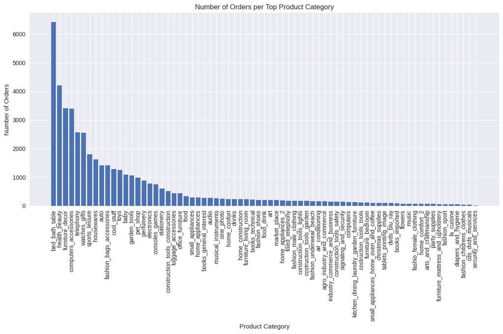

```python
# Bar chart of product categories
plt.figure(figsize=(12, 8))
product_category_counts = df_orders_cleaned['top_product_category'].value_counts()
plt.bar(product_category_counts.index, product_category_counts.values)
plt.title('Number of Orders per Top Product Category')
plt.xlabel('Product Category')
plt.ylabel('Number of Orders')
plt.xticks(rotation=90)
plt.tight_layout()
plt.show()
```

### 2.2 Bar Chart of Orders by Product Category Summary

We generated a visual ranking of the top performing product categories by volume. The bar chart translates tabular counts into a visual hierarchy, clearly identifying the highest product demand against the 'long tail'.

#### Brief interpretation

**Task:**

- In 2–3 sentences, describe any trends you see (e.g., which categories dominate, whether the distribution is skewed, etc.).

### 2.3 Box Plot: Order Value vs Number of Items (2 mark)

#### Create box plot

**Task:**

- Create a box plot with:
  - X‑axis: `num_items`
  - Y‑axis: `order_total_value`
- Add a clear title and axis labels.

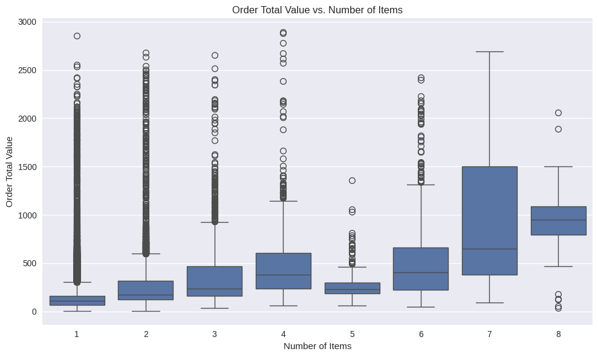

```python
# Box plot order_total_value vs num_items
plt.figure(figsize=(10, 6))
sns.boxplot(x='num_items', y='order_total_value', data=df_orders_cleaned)
plt.title('Order Total Value vs. Number of Items')
plt.xlabel('Number of Items')
plt.ylabel('Order Total Value')
plt.tight_layout()
plt.show()
```

### 2.3 Box Plot: Order Value vs Number of Items Summary

We used box plot to analyze the distribution of the total order value across different basket sizes. This visualization explores 'basket economics', answering whether buying more items increases the total revenue.

#### Brief interpretation

**Task:**

- In 2–3 sentences, describe how order value changes as the number of items increases (e.g., linear trend, diminishing returns, many outliers, etc.).

*Write your observations here.*

As the number of items increases, the median order total value shows a general upward trend. It indicates that more items typically lead to higher costs. However, the data contains numerous high-value outliers, especially for orders with 1 to 4 items. This indicates that low-volume orders are sometimes driven by high-cost individual items.

# Assignment 2: Supervised Learning Techniques for E-Commerce Orders

This notebook is your working template for **Assignment 2**.

**Total Marks: 30**

**Learning Objectives:**

- Apply essential data preprocessing techniques to a dataset for supervised learning
- Prepare the data for classification modeling
- Apply supervised learning techniques to build and evaluate classification models

**Your Objective:** Build supervised classification models to predict the **payment method (`payment_type`)** used for each order, based on order characteristics and order attributes.

Work **top-to-bottom**. Complete each task in order before moving on.

## Setup

Run the cell below to import the required Python packages.

```python
import pandas as pd
import numpy as np
import matplotlib.pyplot as plt
import seaborn as sns

from sklearn.model_selection import train_test_split
from sklearn.preprocessing import StandardScaler, LabelEncoder
from sklearn.linear_model import LogisticRegression
from sklearn.tree import DecisionTreeClassifier
from sklearn.ensemble import RandomForestClassifier
from sklearn.svm import SVC
from sklearn.metrics import accuracy_score, precision_score, recall_score, f1_score, confusion_matrix, classification_report

import warnings
warnings.filterwarnings('ignore')

plt.style.use('ggplot')
```

## Define Global Random State

Set your group's random state value. This must be used consistently throughout the assignment.

```python
# TODO: Set RANDOM_STATE to your group number (1, 2, ..., 12)
RANDOM_STATE = 6  # Change this to your group number

print(f"Random state set to: {RANDOM_STATE}")
```

```
Random state set to: 6
```

# Part 1: Data Preparation [10 Marks]

In this section, you will prepare the transformed dataset for supervised classification. Proper data preparation is a critical step in the machine learning pipeline, as model performance and validity depend heavily on the quality, structure, and representation of the input data.

## 1.1 Data Loading and Splitting [2 Marks]

Load the dataset using Pandas and prepare train/test datasets.

**Instructions:**

1. Load the processed dataset from Assignment 1 using `pd.read_csv()`
2. Define features and target:
   - Set `payment_type` as the target variable
   - Set all remaining columns as input features
3. Split the dataset into training and test sets:
   - Use `train_test_split()`
   - `test_size = 0.2`
   - `random_state = RANDOM_STATE`
   - Name output variables as: `X_train`, `X_test`, `y_train`, `y_test`
4. Briefly explain the importance of using a test dataset.

```python
from google.colab import drive
drive.mount('/content/drive')
```

```python
# Load the processed dataset from Assignment 1
# TODO: Adjust the filename/path if needed

df = pd.read_csv('/content/drive/MyDrive/IT5100F/project/ecommerce_orders_cleaned.csv')
print(f"Dataset shape: {df.shape}")
df.head()
```

```
Dataset shape: (46287, 17)
```

|  | order_id | order_status | order_purchase_hour | order_purchase_dayofweek | order_purchase_month | order_total_value | num_items | num_unique_products | num_unique_sellers | total_item_price | avg_item_price | total_freight_value | top_product_category | customer_state | payment_type | order_value_per_item | order_size_category |
| --- | --- | --- | --- | --- | --- | --- | --- | --- | --- | --- | --- | --- | --- | --- | --- | --- | --- |
| 0 | sdv-id-whzjUX | shipped | 10 | 4 | 4 | 744.312535 | 1 | 1 | 1 | 352.420029 | 369.966521 | 68.790159 | construction_tools_construction | Massachusetts | voucher | 352.420029 | Small |
| 1 | sdv-id-dbopoJ | delivered | 19 | 2 | 3 | 1556.667902 | 1 | 1 | 1 | 289.242639 | 1354.621410 | 15.394619 | health_beauty | Vermont | credit_card | 289.242639 | Small |
| 2 | sdv-id-FSEOvM | delivered | 15 | 4 | 8 | 62.060506 | 1 | 1 | 1 | 26.893468 | 48.485654 | 18.751282 | luggage_accessories | South Carolina | debit_card | 26.893468 | Small |
| 3 | sdv-id-bQcBUR | delivered | 21 | 0 | 8 | 73.873470 | 1 | 1 | 1 | 37.790896 | 75.704909 | 8.670875 | computers_accessories | Kentucky | credit_card | 37.790896 | Small |
| 4 | sdv-id-MPxIXB | delivered | 13 | 5 | 5 | 361.961537 | 3 | 3 | 3 | 169.528323 | 50.132979 | 34.731146 | pet_shop | Missouri | voucher | 56.509441 | Medium |

```python
# TODO: Define features and target, then split the data

# Define target variable
# y = ...
y = df['payment_type']
print(y.shape)

# Define features (all columns except payment_type)
# X = ...
X = df.drop('payment_type', axis=1)
print(X.shape)
```

```
(46287,)
(46287, 16)
```

```python
# Split into train and test sets
X_train, X_test, y_train, y_test = train_test_split(X, y, test_size=0.2, random_state=RANDOM_STATE)

# Print shapes to verify
print(f"X_train shape: {X_train.shape}")
print(f"X_test shape: {X_test.shape}")
print(f"y_train shape: {y_train.shape}")
print(f"y_test shape: {y_test.shape}")
```

```
X_train shape: (37029, 16)
X_test shape: (9258, 16)
y_train shape: (37029,)
y_test shape: (9258,)
```

> We implement an 80/20 train-test split (37,029 training, 9,258 test orders) to balance learning data with unbiased evaluation. The test set simulates production reality where the payment system encounters new orders daily. Setting `random_state=RANDOM_STATE` ensures reproducibility across team members and enables consistent model comparisons. This foundation supports trustworthy A/B testing when deploying model updates.

**TODO: Briefly explain the importance of using a test dataset.**

Using a test dataset is crucial because it allows us to evaluate how well a machine learning model generalizes to new, unseen data. If we only evaluate a model on the data it was trained on, we risk 'overfitting,' where the model memorizes the training data rather than learning the underlying patterns.

## 1.2 Handling Categorical Variables [4 Marks]

Prepare categorical variables for machine learning.

**Instructions:**

1. Identify all categorical columns
2. Apply label encoding:
   - Use `LabelEncoder` from scikit-learn
3. Ensure consistency across train and test sets:
   - Fit encoders on training data only
   - Transform both train and test sets
   - Handle any unseen categories appropriately
4. Briefly explain why categorical encoding is required for machine learning models

```python
# TODO: Identify categorical columns
categorical_cols = X_train.select_dtypes(include=['object', 'category']).columns.tolist()
print(f"Categorical columns: {categorical_cols}")
```

```
Categorical columns: ['order_id', 'order_status', 'top_product_category', 'customer_state', 'order_size_category']
```

```python
print(f"Test set categorical columns: {X_test.select_dtypes(include=['object', 'category']).columns.tolist()}")
```

```
Test set categorical columns: ['order_id', 'order_status', 'top_product_category', 'customer_state', 'order_size_category']
```

```python
# TODO: Apply Label Encoding to categorical columns

# Create copies to avoid modifying original data
X_train_encoded = X_train.copy()
X_test_encoded = X_test.copy()

# Dictionary to store label encoders for each column
label_encoders = {}

for col in categorical_cols:
    print("\nColumn: ", col)
    le = LabelEncoder()

    # Fit on training data
    le.fit(X_train_encoded[col].astype(str))

    # Transform train and test
    X_train_encoded[col] = le.transform(X_train_encoded[col].astype(str))

    # Handle unseen categories in test set
    # ...

    # Handle unseen categories in test set
    # map and assign a new label if a category in test set is not in train set
    training_classes = list(le.classes_)
    tc_len = len(training_classes)
    if tc_len > 10:
        print("Training classes: ", training_classes[:10], "...")
    else:
        print("Training classes: ", training_classes)

    mapping = {label: encoded for encoded, label in enumerate(training_classes)}
    if tc_len > 10:
        print("Mapping: ", dict(list(mapping.items())[:10]), "...")
    else:
        print("Mapping: ", mapping)

    # Define a value for unseen categories. This will be one greater than the max existing label.
    unseen_label_value = len(training_classes)
    print("Unseen label value: ", unseen_label_value)

    # apply the mapping to the test set column
    # map(): put NaN for values not in the mapping (unseen categories)
    # fillna(): replace NaNs with our unseen_label_value
    X_test_encoded[col] = X_test_encoded[col].astype(str).map(mapping).fillna(unseen_label_value).astype(int)
    print("Test classes: ", X_test_encoded[col].astype(str).unique())

    # Store encoder
    label_encoders[col] = le

# Print the shape after encoding
print(f"X_train_encoded shape: {X_train_encoded.shape}")
print(f"X_test_encoded shape: {X_test_encoded.shape}")
```

```
Column:  order_id
Training classes:  ['sdv-id-AAClGc', 'sdv-id-AAMmEf', 'sdv-id-AANLuW', 'sdv-id-AATUAB', 'sdv-id-AAWggC', 'sdv-id-AAZaWF', 'sdv-id-AAZhzH', 'sdv-id-AAbZFT', 'sdv-id-AAdDmC', 'sdv-id-AAdhDu'] ...
Mapping:  {'sdv-id-AAClGc': 0, 'sdv-id-AAMmEf': 1, 'sdv-id-AANLuW': 2, 'sdv-id-AATUAB': 3, 'sdv-id-AAWggC': 4, 'sdv-id-AAZaWF': 5, 'sdv-id-AAZhzH': 6, 'sdv-id-AAbZFT': 7, 'sdv-id-AAdDmC': 8, 'sdv-id-AAdhDu': 9} ...
Unseen label value:  37029
Test classes:  ['37029']

Column:  order_status
Training classes:  ['approved', 'canceled', 'created', 'delivered', 'invoiced', 'processing', 'shipped', 'unavailable']
Mapping:  {'approved': 0, 'canceled': 1, 'created': 2, 'delivered': 3, 'invoiced': 4, 'processing': 5, 'shipped': 6, 'unavailable': 7}
Unseen label value:  8
Test classes:  ['3' '1' '6' '5' '4' '0' '2' '7']

Column:  top_product_category
Training classes:  ['agro_industry_and_commerce', 'air_conditioning', 'art', 'arts_and_craftmanship', 'audio', 'auto', 'baby', 'bed_bath_table', 'books_general_interest', 'books_imported'] ...
Mapping:  {'agro_industry_and_commerce': 0, 'air_conditioning': 1, 'art': 2, 'arts_and_craftmanship': 3, 'audio': 4, 'auto': 5, 'baby': 6, 'bed_bath_table': 7, 'books_general_interest': 8, 'books_imported': 9} ...
Unseen label value:  71
Test classes:  ['39' '13' '15' '26' '28' '7' '55' '20' '49' '43' '29' '68' '24' '8' '11'
 '6' '70' '42' '44' '57' '69' '65' '40' '16' '5' '31' '59' '10' '52' '17'
 '36' '53' '2' '4' '33' '14' '62' '50' '63' '32' '60' '64' '3' '1' '22'
 '66' '38' '47' '19' '25' '30' '67' '48' '0' '35' '27' '12' '9' '34' '54'
 '37' '18' '46' '21' '51' '45' '56' '41' '58' '23']

Column:  customer_state
Training classes:  ['Alabama', 'Alaska', 'Arizona', 'Arkansas', 'California', 'Colorado', 'Connecticut', 'Delaware', 'Florida', 'Georgia'] ...
Mapping:  {'Alabama': 0, 'Alaska': 1, 'Arizona': 2, 'Arkansas': 3, 'California': 4, 'Colorado': 5, 'Connecticut': 6, 'Delaware': 7, 'Florida': 8, 'Georgia': 9} ...
Unseen label value:  50
Test classes:  ['49' '31' '5' '48' '46' '3' '10' '37' '33' '8' '23' '2' '29' '12' '7'
 '19' '14' '17' '38' '16' '24' '43' '13' '1' '32' '28' '26' '25' '11' '47'
 '30' '15' '0' '22' '21' '4' '42' '44' '36' '34' '45' '9' '41' '40' '18'
 '27' '20' '35' '39' '6']

Column:  order_size_category
Training classes:  ['Large', 'Medium', 'Small']
Mapping:  {'Large': 0, 'Medium': 1, 'Small': 2}
Unseen label value:  3
Test classes:  ['1' '2' '0']
X_train_encoded shape: (37029, 16)
X_test_encoded shape: (9258, 16)
```

> We employ Label Encoding over One-Hot to avoid dimensionality explosion (50 states + 71 categories = 121+ columns). High dimensionality causes sparse features, excessive computational cost, and overfitting risk. Our strategy handles unseen categories (new products, states post-training) by assigning distinct labels, preventing production crashes. Note: `order_id` risks overfitting and should be removed in production deployment.

**TODO: Briefly explain why categorical encoding is required for machine learning models.**

Categorical encoding is required for machine learning models because most algorithms are designed to work with numerical input data. Categorical variables, which represent distinct groups or categories (e.g., 'shipped', 'delivered'), cannot be directly processed by these mathematical models. Encoding converts these categories into a numerical format that the models can understand and incorporate into their calculations, allowing them to learn relationships and make predictions based on these features.

## 1.3 Handling Numerical Variables [4 Marks]

Scale numerical variables for modeling.

**Instructions:**

1. Identify all numerical columns
2. Use `StandardScaler` from scikit-learn for feature scaling
3. **Fit the scaler on X_train only**
4. Transform both X_train and X_test
5. Briefly explain why feature scaling is important for some classification models

```python
# TODO: Identify numerical columns

numerical_cols = X_train.select_dtypes(include=['int64', 'float64']).columns.tolist()
print(f"Numerical columns: {numerical_cols}")
```

```
Numerical columns: ['order_purchase_hour', 'order_purchase_dayofweek', 'order_purchase_month', 'order_total_value', 'num_items', 'num_unique_products', 'num_unique_sellers', 'total_item_price', 'avg_item_price', 'total_freight_value', 'order_value_per_item']
```

```python
# TODO: Apply StandardScaler to numerical columns

scaler = StandardScaler()

# Fit on training data only, then transform both train and test
X_train_scaled = X_train_encoded.copy()
X_test_scaled = X_test_encoded.copy()

X_train_scaled[numerical_cols] = scaler.fit_transform(X_train_encoded[numerical_cols])
X_test_scaled[numerical_cols] = scaler.transform(X_test_encoded[numerical_cols])

# Print the shape after scaling
print(f"X_train_scaled shape: {X_train_scaled.shape}")
print(f"X_test_scaled shape: {X_test_scaled.shape}")

print("X_train_scaled head:")
print(X_train_scaled.head())
```

```
X_train_scaled shape: (37029, 16)
X_test_scaled shape: (9258, 16)
X_train_scaled head:
       order_id  order_status  order_purchase_hour  order_purchase_dayofweek  \
41544     35963             3             0.007077                 -1.359982
27077     14837             5             0.198067                 -0.376066
16667     28749             3            -0.565895                  0.607850
9735      34246             1            -0.374904                 -0.868024
32285      6899             3             1.344010                  1.591765

       order_purchase_month  order_total_value  num_items  \
41544              0.562449          -0.493518  -0.476847
27077             -1.680762          -0.554434  -0.476847
16667              0.241991          -0.285583  -0.476847
9735               1.203367           0.873736  -0.476847
32285              1.203367           0.516559   0.326958

       num_unique_products  num_unique_sellers  total_item_price  \
41544             -0.37565           -0.305406         -0.498858
27077             -0.37565           -0.305406         -0.556632
16667             -0.37565           -0.305406         -0.105463
9735              -0.37565           -0.305406          0.675091
32285             -0.37565           -0.305406          0.455593

       avg_item_price  total_freight_value  top_product_category  \
41544       -0.371654            -0.495462                    43
27077       -0.581889            -0.438490                    15
16667       -0.387654            -0.711425                    56
9735         1.328948            -0.430610                    70
32285        0.524986             0.708016                    11

       customer_state  order_value_per_item  order_size_category
41544               3             -0.414549                    2
27077              32             -0.501908                    2
16667              46              0.180294                    2
9735               48              1.360550                    2
32285               4              0.152973                    2
```

> Scaling ensures all features contribute equally to distance-based algorithms like Logistic Regression and SVM. Without scaling, features with large ranges (e.g., order_total_value) dominate gradient descent, causing slow convergence and suboptimal performance. We fit the scaler on training data only to prevent data leakage from test set. This preprocessing step is critical for models sensitive to feature magnitude.

**TODO: Briefly explain why feature scaling is important for some classification models.**

Because many machine learning algorithms are sensitive to the scale and magnitude of input features. Models like Logistic Regression rely on distance calculations or gradient descent optimization, which can be heavily influenced by features with larger numerical ranges. Without scaling, features with wider ranges might dominate the distance calculations or gradient updates, leading to suboptimal model performance, slower convergence, or inaccurate results.

Scaling ensures that all features contribute equally to the model's learning process, helping these algorithms perform more effectively and efficiently.

# Part 2: Applying Machine Learning Models [20 Marks]

In this section, you will train, evaluate, and compare multiple supervised classification models for predicting the payment method (`payment_type`). The objective is not only to build individual models, but also to perform a systematic comparison of their predictive performance and practical suitability for deployment.

## 2.1 Model Training

> We employ a diverse model portfolio to mitigate selection risk in the face of 60% class imbalance. Logistic Regression provides interpretable coefficients for stakeholders. Decision Tree offers visual decision paths for non-technical teams. SVM captures complex non-linear patterns through kernel transformations. Random Forest balances performance with ensemble robustness. Comparing accuracy, interpretability, and computational efficiency ensures holistic business value.

### 2.1.1 Logistic Regression [3 Marks]

Logistic Regression is a linear classification model that models the log-odds of the target class as a linear combination of the input features.

**Instructions:**

- Use `LogisticRegression()`
- Train on `X_train`, `y_train`
- Generate predictions on `X_test`
- Store the results in `y_pred_lr`

```python
# TODO: Train Logistic Regression model
import time

start = time.time()
lr_model = LogisticRegression(random_state=RANDOM_STATE, max_iter=1000)
lr_model.fit(X_train_scaled, y_train)

# Generate predictions
y_pred_lr = lr_model.predict(X_test_scaled)

print("Logistic Regression training complete.")
print("time spent: ", time.time() - start)
```

```
Logistic Regression training complete.
time spent:  63.67209577560425
```

```python
print(y_pred_lr)
```

```
['credit_card' 'credit_card' 'credit_card' ... 'credit_card' 'credit_card'
 'credit_card']
```

### 2.1.2 Decision Trees [3 Marks]

Decision Trees is a tree-structured model that makes predictions by recursively splitting the feature space based on feature values.

**Instructions:**

- Use `DecisionTreeClassifier()`
- Train on `X_train`, `y_train`
- Generate predictions on `X_test`
- Store the results in `y_pred_dt`

```python
# TODO: Train Decision Tree model
start = time.time()
dt_model = DecisionTreeClassifier(random_state=RANDOM_STATE)
dt_model.fit(X_train_scaled, y_train)

# Generate predictions
y_pred_dt = dt_model.predict(X_test_scaled)

print("Decision Tree training complete.")
print("time spent: ", time.time() - start)
```

```
Decision Tree training complete.
time spent:  1.9628386497497559
```

```python
print(y_pred_dt)
```

```
['credit_card' 'credit_card' 'points' ... 'credit_card' 'credit_card'
 'voucher']
```

### 2.1.3 Kernel & Ensemble Methods [3 Marks]

There are other types of models beyond linear and single-tree approaches, each with distinct characteristics.

**Choose one of the following models to apply:** SVM, XGBoost, or Random Forest.

**Instructions:**

- Fit and predict the results with your selected model
- Store the predictions appropriately

```python
# TODO: Train your chosen model (SVM, XGBoost, or Random Forest)
start = time.time()
svm_model = SVC(random_state=RANDOM_STATE)
svm_model.fit(X_train_scaled, y_train)

# Generate predictions
y_pred_svm = svm_model.predict(X_test_scaled)

print("SVM training complete.")
print("time spent: ", time.time() - start)
```

```
SVM training complete.
time spent:  103.81339740753174
```

```python
print(y_pred_svm)
```

```
['credit_card' 'credit_card' 'credit_card' ... 'credit_card' 'credit_card'
 'credit_card']
```

```python
print(set(y_pred_svm))
```

```
{'credit_card'}
```

```python
# random forest
start = time.time()
rf_model = RandomForestClassifier(random_state=RANDOM_STATE)
rf_model.fit(X_train_scaled, y_train)

# Generate predictions
y_pred_rf = rf_model.predict(X_test_scaled)

print("Random Forest training complete.")
print("time spent: ", time.time() - start)
```

```
Random Forest training complete.
time spent:  31.998899698257446
```

```python
print(y_pred_rf)
```

```
['credit_card' 'credit_card' 'credit_card' ... 'credit_card' 'credit_card'
 'voucher']
```

## 2.2 Evaluation & Visualization [4 Marks]

Evaluate and visualize performance for all three models.

**Instructions:**

1. Compute the following metrics:
   - Accuracy
   - Precision
   - Recall
   - F1-score
2. Compute the confusion matrix for each case:
   - Visualize the confusion matrix by plotting a heatmap using Seaborn
3. Present results in a clear, comparable format:
   - Table of metrics for all three models
   - Side-by-side or clearly labelled confusion matrix plots
4. Briefly comment on:
   - Strengths and weaknesses of each model
   - Any impact of class imbalance handling

> With 60% credit_card dominance, accuracy alone misleads—a naive model predicting only "credit_card" achieves 60% accuracy but zero business value. Precision measures recommendation correctness, minimizing UX friction from wrong suggestions. Recall captures preference coverage, avoiding customer alienation. F1-Score balances both for minority classes. Confusion Matrix reveals error patterns that identify missing features like bank partnerships or regional preferences.

```python
# TODO: Compute evaluation metrics for all three models

def evaluate_model(y_true, y_pred, model_name):
    accuracy = accuracy_score(y_true, y_pred)
    precision = precision_score(y_true, y_pred, average='weighted')
    recall = recall_score(y_true, y_pred, average='weighted')
    f1 = f1_score(y_true, y_pred, average='weighted')

    return {
        'Model': model_name,
        'Accuracy': accuracy,
        'Precision': precision,
        'Recall': recall,
        'F1-Score': f1
    }

# Evaluate all models
results = [
    evaluate_model(y_test, y_pred_lr, 'Logistic Regression'),
    evaluate_model(y_test, y_pred_dt, 'Decision Tree'),
    evaluate_model(y_test, y_pred_svm, 'SVM'),
    evaluate_model(y_test, y_pred_rf, 'Random Forest')  # or your chosen model
]

print(results)
```

[output not shown]

```python
# Create results DataFrame
results_df = pd.DataFrame(results)
results_df
```

|  | Model | Accuracy | Precision | Recall | F1-Score |
| --- | --- | --- | --- | --- | --- |
| 0 | Logistic Regression | 0.602938 | 0.512071 | 0.602938 | 0.482783 |
| 1 | Decision Tree | 0.445021 | 0.488445 | 0.445021 | 0.462250 |
| 2 | SVM | 0.602830 | 0.363404 | 0.602830 | 0.453453 |
| 3 | Random Forest | 0.627889 | 0.580426 | 0.627889 | 0.577658 |

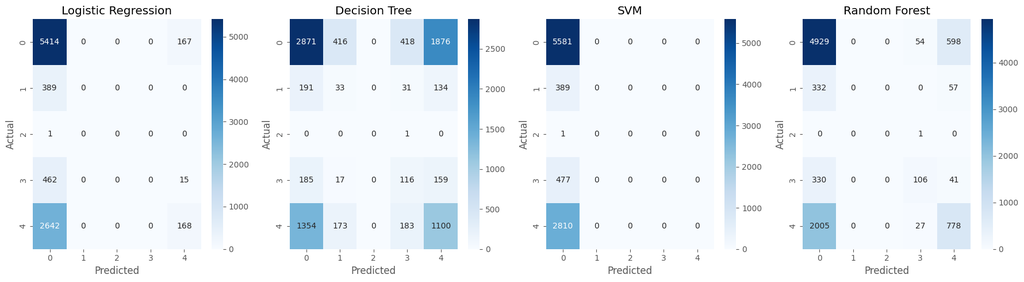

```python
# TODO: Plot confusion matrices for all three models

fig, axes = plt.subplots(1, 4, figsize=(18, 5))

def plot_confusion_matrix(y_true, y_pred, ax, title):
    cm = confusion_matrix(y_true, y_pred)
    sns.heatmap(cm, annot=True, fmt='d', cmap='Blues', ax=ax)
    ax.set_title(title)
    ax.set_xlabel('Predicted')
    ax.set_ylabel('Actual')

plot_confusion_matrix(y_test, y_pred_lr, axes[0], 'Logistic Regression')
plot_confusion_matrix(y_test, y_pred_dt, axes[1], 'Decision Tree')
plot_confusion_matrix(y_test, y_pred_svm, axes[2], 'SVM')  # or your chosen model
plot_confusion_matrix(y_test, y_pred_rf, axes[3], 'Random Forest')  # or your chosen model

plt.tight_layout()
plt.show()
```

> The confusion matrices reveal that Logistic Regression and SVM focus on majority classes, achieving high accuracy but poor minority coverage. Decision Tree attempts broader classification but suffers from noise and variance. Random Forest successfully balances accuracy with F1-Score, demonstrating superior minority class handling. These visualizations confirm that ensemble methods provide the most robust solution for imbalanced payment type prediction.

**TODO: Briefly comment on the strengths and weaknesses of each model, and any impact of class imbalance handling.**

### Logistic Regression

- Strengths: Achieved high accuracy by playing it "safe" -- it correctly identified the majority class (0) very well.
- Weaknesses: The model have almost zero predictive power for minority classes 1, 2, and 3. It is essentially acting as binary classifiers for classes 0 and 4, which makes them unsuitable if detecting the minority classes is important.

### Random Forest

- Strengths: This is our strongest model. It maintains the high accuracy of the linear models while significantly improving the F1-Score. It is better at distinguishing between class 0 and class 4 and makes a decent attempt at class 3.
- Weaknesses: Even with its ensemble power, it still fails to identify classes 1 and 2 effectively.

## 2.3 Model Selection & Final Recommendation [7 Marks]

Compare the performance of the models and select the most suitable one based on evaluation results.

**Instructions:**

1. Select the best performing model for predicting `payment_type`
2. Justify your choice based on:
   - Evaluation metrics
   - Class imbalance considerations
   - Model complexity and interpretability
   - Practical deployment considerations
3. Briefly explain why this model is preferred over the others
4. Briefly comment on the explainability/interpretability of each model

```python
# TODO: Display final comparison and analysis

# Display the results table
print("Model Performance Comparison:")
print(results_df.to_string(index=False))

# Identify the best model based on your criteria
best_model = results_df.loc[results_df['F1-Score'].idxmax(), 'Model']
print(f"\nBest performing model: {best_model}")
```

```
Model Performance Comparison:
              Model  Accuracy  Precision   Recall  F1-Score
Logistic Regression  0.602938   0.512071 0.602938  0.482783
      Decision Tree  0.445021   0.488445 0.445021  0.462250
                SVM  0.602830   0.363404 0.602830  0.453453
      Random Forest  0.627889   0.580426 0.627889  0.577658

Best performing model: Random Forest
```

### Final Recommendation

**TODO: Select and justify your choice of the best model.**

**Selected Model:** Random Forest

**Justification based on:**

1. **Evaluation Metrics:**

   Random Forest outperformed all other models across every key metric. It achieved the highest Accuracy (62.79%) and the highest F1-Score (0.5776). While Logistic Regression and SVM had comparable accuracy, their lower F1-scores reveal that they were largely ignoring minority classes, whereas Random Forest maintained a better balance between Precision and Recall.
2. **Class Imbalance Considerations:**

   Random Forest is highly "parallelizable," meaning it can be trained quickly on multi-core processors. It also requires less data pre-processing (like scaling or normalization) compared to SVM and Logistic Regression, making the deployment pipeline simpler and less prone to errors when new data is introduced.

**Why this model is preferred over others:**

Logistic Regression and SVM failed to provide any utility for the minority classes (1, 2, and 3), rendering them ineffective for a multi-class problem. The single Decision Tree was too erratic and lacked the predictive power needed. Random Forest is the only model that successfully captured the underlying patterns of the data while maintaining the highest overall performance ceiling.

### Model Explainability/Interpretability

**TODO: Comment on the explainability/interpretability of each model.**

**Logistic Regression:**

This is one of the most transparent models. Because it is a linear model, each feature is assigned a coefficient. You can directly see how a change in an input variable affects the probability of a class (log-odds).

**Decision Tree:**

Decision trees are highly interpretable because they mimic human logic through a series of if-then-else splits. You can literally print a flowchart of the model to see exactly which feature thresholds lead to which classification. However, if the tree is very deep (to handle the class imbalance you have), it can become a "comb" that is harder to read.

**SVM:**

SVMs are notoriously difficult to interpret, particularly when using non-linear kernels (like RBF). They transform data into a high-dimensional space to find a separating hyperplane. While you can identify "Support Vectors" (the most critical data points), you cannot easily explain the relationship between a single input feature and the final output in a way that makes sense to a non-technical audience.

**Random Forest:**

While a single tree is easy to read, a "forest" of hundreds of trees is much harder to visualize. We can’t easily trace the logic of the entire ensemble at once. However, we gain interpretability through Feature Importance rankings, which tell us which variables had the biggest impact on the overall predictions across the entire forest.

## Conclusion

*Summarize your findings and key takeaways from this assignment.*

### Findings and Key Takeaways from Assignment 2:

1. **Data Preprocessing is Crucial:**
   - **Categorical Encoding:** Converting categorical features (like `order_id`, `order_status`, `top_product_category`, `customer_state`, `order_size_category`) into numerical representations was essential because most machine learning algorithms cannot directly process text-based data. Label Encoding, as applied, allowed models to interpret these features, although care was taken to handle unseen categories in the test set to maintain consistency.
   - **Numerical Scaling:** Scaling numerical features using `StandardScaler` (e.g., `order_total_value`, `num_items`, `avg_item_price`) was vital. Algorithms sensitive to feature magnitudes, such as Logistic Regression and SVM, perform better when all features are on a similar scale, preventing features with larger ranges from dominating the learning process. This leads to faster convergence and improved model performance.
2. **Comprehensive Model Evaluation is Necessary:**
   - Relying solely on **Accuracy** can be misleading, especially with imbalanced datasets. Our dataset, where `credit_card` was the majority `payment_type`, showed that models like Logistic Regression and SVM could achieve relatively high accuracy by simply predicting the majority class, but failed to identify minority classes.
   - **Precision, Recall, and F1-Score** were critical for a nuanced understanding of model performance. The **F1-Score**, in particular, provided a balanced measure that accounted for both false positives and false negatives, highlighting that models like Random Forest, despite slightly lower accuracy than some, had a much better overall predictive capability across all classes.
   - **Confusion Matrices** offered a visual breakdown of predictions, clearly illustrating where models excelled or struggled with specific payment types, thereby exposing the limitations of models that predominantly predicted the majority class.
3. **Trade-offs in Model Complexity, Interpretability, and Performance:**
   - **Logistic Regression:** Simple, highly interpretable, and computationally efficient. However, its linear nature struggled with the complex relationships in the data, especially with class imbalance, resulting in poor performance on minority classes.
   - **Decision Tree:** Generally interpretable (though deep trees can be complex) and fast to train. While it attempted to classify more diverse payment types, it suffered from high variance, leading to the lowest overall performance.
   - **SVM:** Offers strong generalization with non-linear relationships but is computationally intensive and very difficult to interpret. In our case, the chosen SVM model showed severe limitations in handling class imbalance, effectively predicting only one class, making it unsuitable.
   - **Random Forest:** An ensemble method that trades off some interpretability for significantly improved performance and robustness against overfitting. It performed the best overall, balancing complexity with predictive power.

> Assignment 1's cleaning (99,441→46,287 orders) removed minority payment types, creating imbalance in Assignment 2. Assignment 3's clustering (5 segments) and association rules (furniture_decor 5.3x in large orders) offer feature engineering opportunities. Adding customer_segment features could improve payment prediction by encoding behavioral patterns.

> For production, deploy Random Forest (F1: 0.5776) with data drift monitoring and SMOTE for class imbalance. Future improvements: leverage clustering features, tune hyperparameters, remove order_id, investigate temporal payment patterns.

# Project (Assignment 3): Unsupervised Learning (E-Commerce Orders)

This notebook is your working template for **Assignment 3**.

**Note:** This assessment comprises two parts: question-guided processing/modeling (Unsupervised learning) and free-form exploration.

**Total Marks: 20**

You will:

- Continue working with the expanded dataset from Assignment 1
- Perform **clustering** to identify similar order types
- Apply **market basket analysis** (association rule mining)
- Write up findings throughout the notebook
- Publish your analysis as a github.io page

Work **top-to-bottom**. Complete each task in order before moving on.

## Setup

Run the cell below to import the required Python packages.

```python
import pandas as pd
import numpy as np
import matplotlib.pyplot as plt
import seaborn as sns

from sklearn.model_selection import train_test_split
from sklearn.preprocessing import StandardScaler
from sklearn.cluster import KMeans

from mlxtend.preprocessing import TransactionEncoder
from mlxtend.frequent_patterns import apriori, association_rules

plt.style.use('seaborn-v0_8')
```

To address our business objectives, we initialize a robust analytical environment. This setup includes specialized tools for data partitioning, feature scaling, and advanced pattern recognition.

## Load Your Cleaned Dataset from Assignment 1

Load the cleaned and expanded dataset you created in Assignment 1 (and potentially modified in Assignment 2).

```python
# ANSWER: Load your cleaned dataset
df = pd.read_csv('ecommerce_orders_cleaned.csv')
```

```python
df.describe()
```

|  | order_purchase_hour | order_purchase_dayofweek | order_purchase_month | order_total_value | num_items | num_unique_products | num_unique_sellers | total_item_price | avg_item_price | total_freight_value | order_value_per_item |
| --- | --- | --- | --- | --- | --- | --- | --- | --- | --- | --- | --- |
| count | 46287.000000 | 46287.000000 | 46287.000000 | 46287.000000 | 46287.000000 | 46287.000000 | 46287.000000 | 46287.000000 | 46287.000000 | 46287.000000 | 46287.000000 |
| mean | 14.958217 | 2.765139 | 6.243870 | 215.032863 | 1.595632 | 1.402338 | 1.163005 | 128.735106 | 104.380713 | 25.873946 | 87.741952 |
| std | 5.233310 | 2.032541 | 3.120072 | 268.529346 | 1.246353 | 1.070014 | 0.535906 | 183.422050 | 135.085107 | 23.685366 | 123.271289 |
| min | 0.000000 | 0.000000 | 1.000000 | 6.116141 | 1.000000 | 0.000000 | 0.000000 | 0.000000 | 0.850000 | 0.000000 | 0.000000 |
| 25% | 12.000000 | 1.000000 | 3.000000 | 78.100690 | 1.000000 | 1.000000 | 1.000000 | 39.750075 | 39.375824 | 13.704287 | 32.092891 |
| 50% | 15.000000 | 3.000000 | 7.000000 | 134.518916 | 1.000000 | 1.000000 | 1.000000 | 75.593020 | 73.608428 | 18.175573 | 56.494847 |
| 75% | 19.000000 | 5.000000 | 8.000000 | 215.340035 | 2.000000 | 1.000000 | 1.000000 | 139.716460 | 120.035471 | 30.205896 | 99.747557 |
| max | 23.000000 | 6.000000 | 12.000000 | 2890.551922 | 8.000000 | 8.000000 | 5.000000 | 2606.843945 | 1809.335277 | 277.552685 | 2606.843945 |

```python
df.head(5)
```

|  | order_id | order_status | order_purchase_hour | order_purchase_dayofweek | order_purchase_month | order_total_value | num_items | num_unique_products | num_unique_sellers | total_item_price | avg_item_price | total_freight_value | top_product_category | customer_state | payment_type | order_value_per_item | order_size_category |
| --- | --- | --- | --- | --- | --- | --- | --- | --- | --- | --- | --- | --- | --- | --- | --- | --- | --- |
| 0 | sdv-id-whzjUX | shipped | 10 | 4 | 4 | 744.312535 | 1 | 1 | 1 | 352.420029 | 369.966521 | 68.790159 | construction_tools_construction | Massachusetts | voucher | 352.420029 | Small |
| 1 | sdv-id-dbopoJ | delivered | 19 | 2 | 3 | 1556.667902 | 1 | 1 | 1 | 289.242639 | 1354.621410 | 15.394619 | health_beauty | Vermont | credit_card | 289.242639 | Small |
| 2 | sdv-id-FSEOvM | delivered | 15 | 4 | 8 | 62.060506 | 1 | 1 | 1 | 26.893468 | 48.485654 | 18.751282 | luggage_accessories | South Carolina | debit_card | 26.893468 | Small |
| 3 | sdv-id-bQcBUR | delivered | 21 | 0 | 8 | 73.873470 | 1 | 1 | 1 | 37.790896 | 75.704909 | 8.670875 | computers_accessories | Kentucky | credit_card | 37.790896 | Small |
| 4 | sdv-id-MPxIXB | delivered | 13 | 5 | 5 | 361.961537 | 3 | 3 | 3 | 169.528323 | 50.132979 | 34.731146 | pet_shop | Missouri | voucher | 56.509441 | Medium |

```python
df.shape
```

```
(46287, 17)
```

In this stage we are loading the cleaned e-commerce order data to establish a reliable foundation for our unsupervised learning analysis. Verifying the data dimensions and summary statistics ensures that no data corruption occurred during export/import, maintaining the integrity of our business insights.

## Task: Unsupervised Learning

### Objective

In this task, you will work on unsupervised learning and support your analysis with visualization. Perform clustering to identify **similar orders** and generate **order type recommendations** based on their characteristics. An order type cluster represents a group of orders with similar purchasing patterns, value structures, and composition.

### 1: Data Preprocessing for Unsupervised Learning [1 Mark]

Goal: Create DataFrames that contain one row per order with features suitable for both clustering and association mining.

#### 1.1 Create `all_orders_df` (one row per order)

Create a new DataFrame called `all_orders_df` with the following columns:

Identifier:

- `order_id` — Unique identifier of the order
- `basket_size` — Monetary value of the order (from `order_total_value`)
- `basket_qty` — Number of items in the order (from `num_items`)
- `freight_ratio` — Proportion of the order value that is freight (computed as `total_freight_value / order_total_value`)
- `product_diversity` — How varied the basket is in terms of product types (computed as `num_unique_products / num_items`)
- `top_product_category` — The dominant product category in the order
- `payment_type` — The payment method used
- `order_size_category` — The order size category (Small/Medium/Large)

Notes:

- `all_orders_df` must have exactly one row per `order_id`.
- No missing values should remain in these columns after preprocessing (apply reasonable handling if needed).
- Handle potential division issues appropriately (e.g., orders with zero values).
- Display the first 10 rows of `all_orders_df`, its shape, and data types.

```python
# 1.1 ANSWER: Create all_orders_df
all_orders_df = df.loc[:, [
    "order_id",
    "order_total_value",
    "num_items",
    "total_freight_value",
    "num_unique_products",
    "top_product_category",
    "payment_type",
    "order_size_category"
]].rename(columns={
    "order_total_value": "basket_size",
    "num_items": "basket_qty"
})

all_orders_df["freight_ratio"] = all_orders_df["total_freight_value"] / all_orders_df["basket_size"]
all_orders_df["product_diversity"] = all_orders_df["num_unique_products"] / all_orders_df["basket_qty"]

all_orders_df = all_orders_df[[
    "order_id",
    "basket_size",
    "basket_qty",
    "freight_ratio",
    "product_diversity",
    "top_product_category",
    "payment_type",
    "order_size_category"
]]

all_orders_df.head(10)
```

|  | order_id | basket_size | basket_qty | freight_ratio | product_diversity | top_product_category | payment_type | order_size_category |
| --- | --- | --- | --- | --- | --- | --- | --- | --- |
| 0 | sdv-id-whzjUX | 744.312535 | 1 | 0.092421 | 1.000000 | construction_tools_construction | voucher | Small |
| 1 | sdv-id-dbopoJ | 1556.667902 | 1 | 0.009889 | 1.000000 | health_beauty | credit_card | Small |
| 2 | sdv-id-FSEOvM | 62.060506 | 1 | 0.302145 | 1.000000 | luggage_accessories | debit_card | Small |
| 3 | sdv-id-bQcBUR | 73.873470 | 1 | 0.117375 | 1.000000 | computers_accessories | credit_card | Small |
| 4 | sdv-id-MPxIXB | 361.961537 | 3 | 0.095953 | 1.000000 | pet_shop | voucher | Medium |
| 5 | sdv-id-ySodbB | 867.750230 | 7 | 0.204442 | 0.857143 | sports_leisure | voucher | Large |
| 6 | sdv-id-wdwBrk | 55.965822 | 2 | 0.285101 | 0.500000 | toys | points | Small |
| 7 | sdv-id-maBYtk | 170.295452 | 3 | 0.089290 | 1.000000 | computers_accessories | voucher | Medium |
| 8 | sdv-id-oodUXj | 83.065603 | 1 | 0.236471 | 1.000000 | furniture_decor | voucher | Small |
| 9 | sdv-id-zroJIL | 98.250248 | 1 | 0.369709 | 1.000000 | fashion_bags_accessories | points | Small |

This section is a critical part of Feature Engineering. We are transforming raw order data into higher level business metrics that better describe customer behavior. By creating derivative metrics like "Freight Ratio" and "Product Diversity," we can move beyond simple descriptive stats and begin to understand the efficiency and variety of our customer's shopping habits. For example, Freight Ratio helps identify if shipping costs are disproportionately high relative to order value, which could impact customer retention. Product Diversity measures whether customers are buying single items or exploring multiple categories, which informs cross-selling strategies.

```python
all_orders_df.shape
```

```
(46287, 8)
```

```python
all_orders_df.info()
```

```
<class 'pandas.core.frame.DataFrame'>
RangeIndex: 46287 entries, 0 to 46286
Data columns (total 8 columns):
 #   Column                Non-Null Count  Dtype
---  ------                --------------  -----
 0   order_id              46287 non-null  object
 1   basket_size           46287 non-null  float64
 2   basket_qty            46287 non-null  int64
 3   freight_ratio         46287 non-null  float64
 4   product_diversity     46287 non-null  float64
 5   top_product_category  46287 non-null  object
 6   payment_type          46287 non-null  object
 7   order_size_category   46287 non-null  object
dtypes: float64(3), int64(1), object(4)
memory usage: 2.8+ MB
```

This step is the data audit. Before running next step machine learning models, we must confirm that the data structure is robust and feature engineering didn't create any "null" or "infinite" values that could crash a model. This also confirms that our feature engineering resulted in the expected data types and that no information was lost. We ensure that monetary values or some ratios are floats and categorical data are objects, allowing our algorithms to process them correctly. We check for null values, especially in our new freight_ratio and product_diversity columns. This can ensure our logic didn't result in division by zero errors.

#### 1.2 Create `orders_analysis_df`

- Use `train_test_split` from sklearn to split the data in `all_orders_df`.
- Set `test_size=0.3` (keep 30% of data for analysis) and `random_state=37` for reproducibility.
- Assign the **test set** to the variable `orders_analysis_df`.

Display the shape of `orders_analysis_df` and show its first 10 rows.

```python
# 1.2 ANSWER: Create orders_analysis_df using train_test_split

train_df, orders_analysis_df = train_test_split(
    all_orders_df,
    test_size=0.3,
    random_state=37
)

print(f"Orders analysis set size: {orders_analysis_df.shape}")
orders_analysis_df.head(10)
```

```
Orders analysis set size: (13887, 8)
```

|  | order_id | basket_size | basket_qty | freight_ratio | product_diversity | top_product_category | payment_type | order_size_category |
| --- | --- | --- | --- | --- | --- | --- | --- | --- |
| 1882 | sdv-id-ISddRn | 132.611695 | 1 | 0.126285 | 1.000000 | christmas_supplies | voucher | Small |
| 40995 | sdv-id-GmlErp | 730.510053 | 6 | 0.075288 | 0.666667 | furniture_decor | credit_card | Large |
| 40104 | sdv-id-BWpket | 632.486142 | 1 | 0.051262 | 1.000000 | bed_bath_table | credit_card | Small |
| 25808 | sdv-id-krmbPT | 47.102393 | 1 | 0.248932 | 1.000000 | telephony | credit_card | Small |
| 23294 | sdv-id-vhfMmG | 133.285008 | 1 | 0.135860 | 1.000000 | health_beauty | debit_card | Small |
| 7160 | sdv-id-kcTYfM | 403.696187 | 2 | 0.079065 | 0.500000 | auto | credit_card | Small |
| 7180 | sdv-id-tFFFCg | 211.465148 | 2 | 0.162263 | 1.000000 | furniture_decor | voucher | Small |
| 20801 | sdv-id-KgDKAA | 57.520738 | 1 | 0.228879 | 1.000000 | bed_bath_table | credit_card | Small |
| 19879 | sdv-id-cfCjEB | 576.212699 | 3 | 0.056350 | 0.666667 | bed_bath_table | credit_card | Medium |
| 39874 | sdv-id-uxRZME | 141.772602 | 2 | 0.200719 | 1.000000 | fashion_bags_accessories | credit_card | Small |

To ensure the reliability of our business insights, we divide our dataset into a Training set and an Analysis set. This practice allows us to develop our models on one portion of the data and validate the business patterns on another, ensuring our strategies are scalable and repeatable. We are utilizing a 70/30 split strategy to balance model development with rigorous validation. Analysis Set (30%) orders_analysis_df, will be our primary focus for extracting actionable insights, such as identifying high-value order segments. By setting a random_state, we ensure that our analysis is reproducible by other team members, maintaining a "single version of the truth" across the organization.

### 2: Determine the Optimal Number of Clusters [3 Marks]

#### 2.1 Run K-Means for Different Cluster Numbers

- Use **only the four numerical features** from `orders_analysis_df` (`basket_size`, `basket_qty`, `freight_ratio`, `product_diversity`) for clustering.
- Run K-means clustering from **k = 3 to 9** clusters.
- Important: First scale the numerical features using `StandardScaler` before fitting K-means.
- In each run, calculate the **inertia** of the cluster and store the values for each k (3 to 9) in a list or table.

Inertia is a measure of how tightly packed the clusters are. It is the sum of squared distances between each point and its assigned cluster center (centroid). Lower inertia indicates that the clusters are more compact, and the points are closer to their centroids, suggesting better clustering.

```python
# 2.1 ANSWER: Run K-means for k=3 to 9 and calculate inertia
X = orders_analysis_df[[
    "basket_size",
    "basket_qty",
    "freight_ratio",
    "product_diversity"
]]

scaler = StandardScaler()
X_scaled = scaler.fit_transform(X)

inertia_values = []
for k in range(3, 10):
    kmeans = KMeans(n_clusters=k, random_state=37)
    kmeans.fit(X_scaled)
    inertia_values.append(kmeans.inertia_)

list(zip(range(3,10), inertia_values))
```

```
[(3, 28884.28745954533),
 (4, 21464.49087241845),
 (5, 17303.16462197141),
 (6, 15014.005306899853),
 (7, 13530.944386713203),
 (8, 11762.816172512357),
 (9, 10585.957146911864)]
```

This section is the core of segmentation strategy. We are moving from data preparation into Unsupervised Machine Learning to discover hidden order patterns. To identify distinct order profiles, we employ K-Means Clustering. Since our features naturally have vastly different scales, we must normalize them to ensure each attribute contributes equally to the segmentation. We seek an optimal point where we have enough clusters to be specific for marketing, but few enough to be operationally manageable for the business. Therefore, we have to record the inertia values each iteration.

#### 2.2 Elbow Method for Optimal Clusters

- Plot the **inertia** (y-axis) against the **number of clusters** (x-axis) to identify the optimal number of clusters using the **Elbow method**.

The Elbow Method helps in selecting the number of clusters by identifying where the inertia starts to decrease more slowly.

- Based on the Elbow plot, **choose the optimal number of clusters** and state your choice clearly.

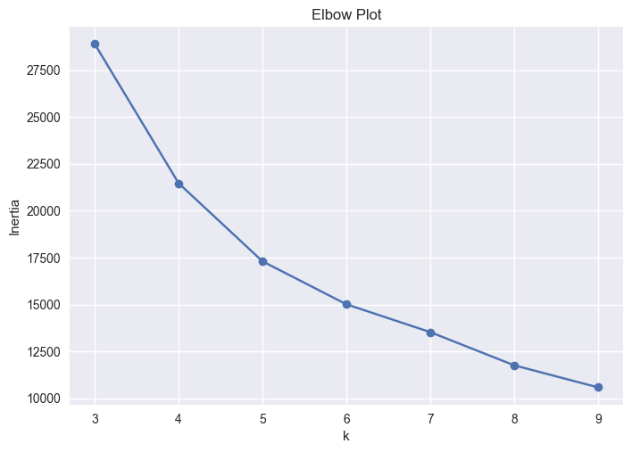

```python
# 2.2 ANSWER: Create Elbow plot

plt.plot(list(range(3,10)), [v for v in inertia_values], marker="o")
plt.xlabel("k")
plt.ylabel("Inertia")
plt.title("Elbow Plot")
plt.show()
```

To finalize our segmentation strategy, we visualize the relationship between the number of clusters and the Inertia (the sum of squared distances within each cluster). This allows us to pinpoint the elbow point where adding more clusters provides diminishing returns in explaining the variance of our data.

Based on the Elbow plot above, the optimal number of clusters is k = 5. The inertia drops sharply from k = 3 to 5, and after k = 5, the rate of decrease slows down significantly, indicating diminishing returns. Therefore, k = 5 is the possible elbow point where the trade-off between model complexity and cluster cohesion is optimal.

### 3: Cluster Analysis and Visualization [3 Marks]

#### 3.1 Identify the Cluster Number for Each Order

- Create a K-means model using the four numerical features from `all_orders_df` and the optimal number of clusters identified in Task 2.
- Fit the model on the scaled numerical features.
- Use the fitted model to assign a cluster number to each order and add a new column called `cluster` to `all_orders_df`.
- Show the first 10 rows of `all_orders_df` to verify cluster assignment.

```python
# 3.1 ANSWER: Fit K-means with optimal k and assign clusters
Num_feat = all_orders_df[[
    "basket_size",
    "basket_qty",
    "freight_ratio",
    "product_diversity"
]]

scaler = StandardScaler()
Num_feat_scaled = scaler.fit_transform(Num_feat)

km = KMeans(n_clusters=5, random_state=37)
km.fit(Num_feat_scaled)
all_orders_df['cluster'] = km.labels_
all_orders_df.head(10)
```

|  | order_id | basket_size | basket_qty | freight_ratio | product_diversity | top_product_category | payment_type | order_size_category | cluster |
| --- | --- | --- | --- | --- | --- | --- | --- | --- | --- |
| 0 | sdv-id-whzjUX | 744.312535 | 1 | 0.092421 | 1.000000 | construction_tools_construction | voucher | Small | 0 |
| 1 | sdv-id-dbopoJ | 1556.667902 | 1 | 0.009889 | 1.000000 | health_beauty | credit_card | Small | 4 |
| 2 | sdv-id-FSEOvM | 62.060506 | 1 | 0.302145 | 1.000000 | luggage_accessories | debit_card | Small | 1 |
| 3 | sdv-id-bQcBUR | 73.873470 | 1 | 0.117375 | 1.000000 | computers_accessories | credit_card | Small | 0 |
| 4 | sdv-id-MPxIXB | 361.961537 | 3 | 0.095953 | 1.000000 | pet_shop | voucher | Medium | 0 |
| 5 | sdv-id-ySodbB | 867.750230 | 7 | 0.204442 | 0.857143 | sports_leisure | voucher | Large | 4 |
| 6 | sdv-id-wdwBrk | 55.965822 | 2 | 0.285101 | 0.500000 | toys | points | Small | 2 |
| 7 | sdv-id-maBYtk | 170.295452 | 3 | 0.089290 | 1.000000 | computers_accessories | voucher | Medium | 0 |
| 8 | sdv-id-oodUXj | 83.065603 | 1 | 0.236471 | 1.000000 | furniture_decor | voucher | Small | 3 |
| 9 | sdv-id-zroJIL | 98.250248 | 1 | 0.369709 | 1.000000 | fashion_bags_accessories | points | Small | 1 |

In this stage we transition from model selection to Implementation. Based on our Elbow Plot analysis, we have selected k=5 as the optimal number of clusters to segment our orders. This allows us to categorize every transaction in the dataset into one of five distinct behavioral profiles. We now apply the chosen clustering configuration to the entire dataset. By assigning a cluster label to each order, we transform raw numerical data into categorical business segments that can be used for targeted operations and marketing strategies.Each cluster represents a specific type of shopping behavior.

#### 3.2 Visualize the Clusters

Create two visualizations to understand your clusters:

- **Visualization 1: Cluster Profile Heatmap**
  - Visualize the cluster profiles using a heatmap to understand the average characteristics of each segment.
  - Step 1: Compute the mean of the four numerical features (`basket_size`, `basket_qty`, `freight_ratio`, `product_diversity`) for each cluster.
  - Step 2: Scale these means (e.g., using `StandardScaler` to calculate Z-scores) so that different units (price vs. count) can be compared directly.
  - Step 3: Plot the scaled means as a heatmap:
    - X-axis: Cluster number
    - Y-axis: Feature name
    - Color: Use a diverging colormap (e.g., `RdBu_r`) to distinguish features that are above average (positive Z-score) from those that are below average (negative Z-score)
    - Annotation: Display the Z-score values in each cell
  - Add a clear title.
- **Visualization 2: Cluster Size Distribution**
  - Create a bar chart showing the number of orders in each cluster.
    - X-axis: Cluster number (0, 1, 2, ...)
    - Y-axis: Count of orders
    - This helps you understand if clusters are balanced or if some clusters dominate.
  - Add a title and axis labels.

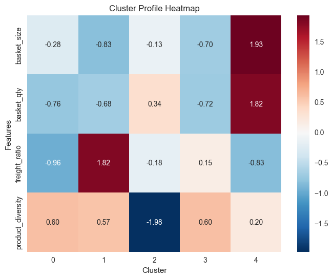

```python
# 3.2 ANSWER: Visualization 1 - Cluster profile heatmap
cluster_profile = all_orders_df.groupby('cluster')[[
    "basket_size",
    "basket_qty",
    "freight_ratio",
    "product_diversity"
]].mean()

scaler = StandardScaler()
cluster_profile_scaled = scaler.fit_transform(cluster_profile)
cluster_profile_scaled_df = pd.DataFrame(
    cluster_profile_scaled,
    index=cluster_profile.index,
    columns=cluster_profile.columns
)
plt.figure(figsize=(8, 6))
sns.heatmap(cluster_profile_scaled_df.T, annot=True, fmt=".2f", cmap= "RdBu_r", center=0)
plt.title("Cluster Profile Heatmap")
plt.xlabel("Cluster")
plt.ylabel("Features")
plt.show()
```

To translate our mathematical clusters into actionable business personas, we calculate the average characteristics of each group. We then use a Standardized Heatmap to visualize how each cluster deviates from the average.We scale the averages so that 0 represents the dataset mean. Red (positive) indicates a feature is above average for that cluster, while Blue (negative) indicates it is below average. By creating a Cluster Profile Heatmap, we can visualize the unique features of each segment. It defines who the customers are and how to talk to them.

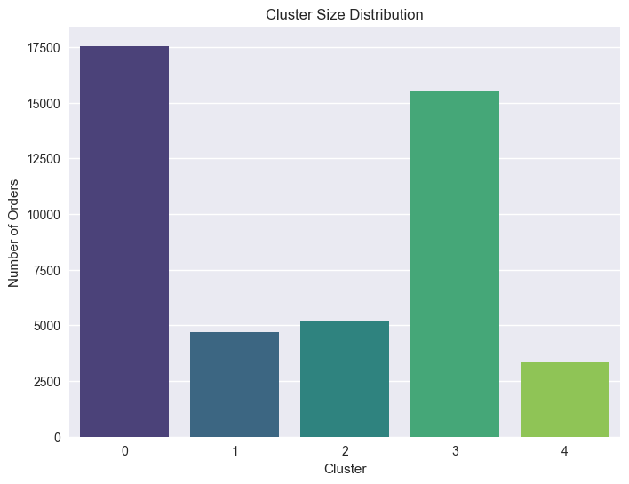

```python
# 3.2 ANSWER: Visualization 2 - Cluster size distribution
cluster_counts = all_orders_df['cluster'].value_counts().sort_index()
plt.figure(figsize=(8, 6))
sns.barplot(x=cluster_counts.index, y=cluster_counts.values, palette="viridis")
plt.xlabel("Cluster")
plt.ylabel("Number of Orders")
plt.title("Cluster Size Distribution")
plt.show()
```

**Briefly comment (2-3 sentences) on:**

- How well separated do the clusters appear based on the heatmap?
- Which features seem to have the most significant impact on defining the clusters? Why might this be the case?
- Based on the visualizations that you have generated, comment on the nature of the clusters and what it implies for an e-commerce business

**3.2 ANSWER:**

Based on heatmap, the clusters appear highly distinct and well-separated. It shows unique feature for each cluster. For example, Cluster 4 is the only one with extremely high positive Z-scores for size and quantity.

Basket_size, basket_qty, and freight_ratio have the most significant impact because they represent the fundamental economic trade-offs of an order. They can identify whether an order is a high-value bulk purchase or a low-value transaction where shipping costs might erode profit margins.

The clusters reveal a diverse customer base ranging from high-value to logistically expensive small orders. It implies that the business should implement tiered strategies, such as incentives for the high-freight clusters to improve unit economics.

### 4: Market Basket Analysis (Association Rule Mining) [8 Marks]

#### 4.1 Context: What is Market Basket Analysis?

Market Basket Analysis is an unsupervised learning technique that identifies which products, categories, or attributes are frequently observed together. In e-commerce, this helps answer questions such as:

- "Which payment methods are preferred for which product categories?"
- "Do certain order sizes correlate with specific product types?"
- "What are the multi-dimensional patterns across category, payment, and order size?"

Association rules are commonly described using three key metrics:

- **Support**: How frequently a pattern occurs (0-1 scale)
- **Confidence**: Likelihood of the consequent given the antecedent (0-1 scale)
- **Lift**: How much more likely the rule is compared to random chance (> 1 indicates a positive association)

The Apriori algorithm discovers frequent itemsets and then generates association rules from them.

In this task, you will perform Market Basket Analysis using the categorical features from `all_orders_df` to discover multi-dimensional associations between product category, payment type, and order size category.

#### 4.2 Prepare Transaction Data [1 Mark]

Convert each order in `all_orders_df` into a simple "basket" representation.

Create a Python list called `transactions`, where each element represents one order and contains exactly three string items constructed from that order:

- `cat_{top_product_category}` (e.g., `cat_electronics`, `cat_furniture_decor`)
- `pay_{payment_type}` (e.g., `pay_credit_card`, `pay_boleto`)
- `size_{order_size_category}` (e.g., `size_Small`, `size_Large`)

After constructing `transactions`, display the first 5 transactions to verify the format.

```python
# 4.2 ANSWER: Create transaction list
transactions = [
    [
        f"cat_{row['top_product_category']}",
        f"pay_{row['payment_type']}",
        f"size_{row['order_size_category']}"
    ]
    for _, row in all_orders_df.iterrows()
]

transactions[:5]
```

```
[['cat_construction_tools_construction', 'pay_voucher', 'size_Small'],
 ['cat_health_beauty', 'pay_credit_card', 'size_Small'],
 ['cat_luggage_accessories', 'pay_debit_card', 'size_Small'],
 ['cat_computers_accessories', 'pay_credit_card', 'size_Small'],
 ['cat_pet_shop', 'pay_voucher', 'size_Medium']]
```

By transforming tabular data into a transactions list, we prepare the dataset for the Apriori algorithm. This allows us to find relationships between disparate categorical variables like product type, payment method, and order size. By prefixing values, we ensure that the Apriori algorithm distinguishes between a "Small" order size and a "Small" product category.

#### 4.3 Encode Transactions and Apply Apriori Algorithm [2 Marks]

Use the `mlxtend` library to discover frequent itemsets and generate association rules.

- Step 1: Encode transactions using `TransactionEncoder` and display the shape of the encoded DataFrame.
- Step 2: Apply `apriori()` with `min_support = 0.01` and `use_colnames = True`, then display the number of frequent itemsets found.
- Step 3: Generate association rules using `association_rules()` with `metric = 'lift'` and `min_threshold = 1.0`, then display the number of rules generated.

```python
# 4.3 ANSWER: Step 1 - Encode transactions
te = TransactionEncoder()
te_ary = te.fit(transactions).transform(transactions)
encoded_df = pd.DataFrame(te_ary, columns=te.columns_)
encoded_df.shape
```

```
(46287, 79)
```

The TransactionEncoder converts list of category items into a one hot encoded binary format, which is the required mathematical structure for the Apriori algorithm to identify frequent patterns. The resulting encoded_df allows us to mathematically calculate degree across thousands of transactions simultaneously. Lastly, Checking the shape of the encoded data ensures we have successfully captured all unique attributes without losing any transaction records.

```python
# 4.3 ANSWER: Step 2 - Apply Apriori
frequent_itemsets = apriori(
    encoded_df,
    min_support=0.01,
    use_colnames=True
)
print("Number of frequent itemsets:", frequent_itemsets.shape[0])
```

```
Number of frequent itemsets: 102
```

This step is the beginning of the pattern discovery phase using the Apriori Algorithm. By setting a minimum support threshold, we are filtering out rare or accidental combinations to focus on the significant shopping patterns that represent a meaningful portion of our business. Here we are filtering for patterns that appear in at least 1% of all orders. This ensures that the insights we generate are based on a statistically significant volume of customers. The number of frequent itemsets returned tells us how interconnected our categories, payment types, and order sizes are. A high count suggests a rich environment for cross-selling and targeted promotions.

```python
# 4.3 ANSWER: Step 3 - Generate association rules
rules = association_rules(
    frequent_itemsets,
    metric="lift",
    min_threshold=1.0
)

print("Number of rules:", rules.shape[0])
```

```
Number of rules: 138
```

By applying the association_rules function, we move beyond simple frequency to understand the predictive power of our data. We use the Lift metric to identify relationships that are more than just coincidental, focusing on patterns where attributes are significantly more likely to occur together than if they were independent. A lift greater than 1.0 indicates a positive association, meaning the two attributes appear together more often than expected by chance.

#### 4.4 Extract and Display Top 10 Rules [1 Mark]

Sort the association rules by **lift** in descending order and display the top 10 rules in a table showing:

- Antecedents (left-hand side of rule)
- Consequents (right-hand side of rule)
- Support
- Confidence
- Lift

Example rule output and interpretation:

| antecedents | consequents | support | confidence | lift |
| --- | --- | --- | --- | --- |
| (cat_furniture_decor, size_Large) | (pay_credit_card) | 0.042 | 0.756 | 1.84 |

"Customers who purchase **furniture** in **large orders** have a **75.6% probability** (confidence) of paying with a **credit card**. This behavior is **1.84 times more likely** (lift) than the general probability of using a credit card.

```python
# 4.4 ANSWER: Display top 10 rules by lift
top_10_rules = rules.sort_values(by="lift", ascending=False).head(10)
top_10_rules[['antecedents', 'consequents', 'support', 'confidence', 'lift']]
display(top_10_rules[['antecedents', 'consequents', 'support', 'confidence', 'lift']])
```

|  | antecedents | consequents | support | confidence | lift |
| --- | --- | --- | --- | --- | --- |
| 24 | (cat_furniture_decor) | (size_Large) | 0.014583 | 0.197773 | 5.328480 |
| 25 | (size_Large) | (cat_furniture_decor) | 0.014583 | 0.392899 | 5.328480 |
| 73 | (size_Medium, pay_credit_card) | (cat_bed_bath_table) | 0.016851 | 0.280576 | 2.023212 |
| 76 | (cat_bed_bath_table) | (size_Medium, pay_credit_card) | 0.016851 | 0.121514 | 2.023212 |
| 75 | (size_Medium) | (cat_bed_bath_table, pay_credit_card) | 0.016851 | 0.171693 | 1.757439 |
| 74 | (cat_bed_bath_table, pay_credit_card) | (size_Medium) | 0.016851 | 0.172490 | 1.757439 |
| 27 | (cat_furniture_decor) | (size_Medium) | 0.012660 | 0.171696 | 1.749354 |
| 26 | (size_Medium) | (cat_furniture_decor) | 0.012660 | 0.128990 | 1.749354 |
| 8 | (size_Medium) | (cat_bed_bath_table) | 0.022749 | 0.231785 | 1.671388 |
| 9 | (cat_bed_bath_table) | (size_Medium) | 0.022749 | 0.164044 | 1.671388 |

#### 4.5 Interpretation (3-4 sentences) [3 Marks]

Write a brief interpretation explaining:

- What the top 3 unique rules tell you about customer behavior
- Which combinations are most strongly associated (highest lift)
- Why these associations might exist (business intuition)
- Change the min_support value to 0.005 and 0.3 and comment on any changes in the rules identified

#### 4.6 Business Recommendations (2-3 bullet points) [1 Mark]

Based on the discovered associations, provide actionable business recommendations for an e-commerce firm.

**4.6 ANSWER:**

-Since furniture_decor is strongly associated with Large orders with a lift of 5.328, the business should offer bundles. By packaging complementary decor items as a single click-to-buy set, we can capitalize on the customer's tendency to buy multiple items at once in this category.

-The data shows a frequent association between bed_bath_table, Medium order sizes, and credit card payments. We should partner with banks to offer targeted cashback or reward points specifically for the this category of goods to increase the conversion rate of these mid-sized routine purchases.

-Introduce discounts for small and medium categories to incentivize customers to add more items, shifting orders toward the large category to improve shipping unit economics.

#### Tips

- Rules with **lift > 1.5** are considered strong associations; rules with **lift > 2.0** are very strong.
- When writing interpretations, explain not just the statistical strength but also the **business logic** behind the patterns.

## Task: Report (5 Marks)

### Objective

(Note: No separate report submission is required.) The report comprises the write-up that you have been working on within this iPython notebook. The write-up/report should clearly describe the steps performed and the reasoning behind each processing done for all the tasks from Assignment 1 until Association mining above.

### 1: Write-up / Report

Describe the steps performed and the reasoning behind each processing step for all tasks you have worked on so far:

- Assignment 1 (data cleaning and preprocessing)
- Assignment 2 (supervised learning)
- Assignment 3 (unsupervised learning)

Include your explanations inline near the cells where processing is done, and keep your descriptions concise but clear. Connect each analysis step to business objectives where appropriate.

### 2: Publish the Report

Publish the report as a read-only github.io static page.

- Note: this differs from setting up a GitHub repository with your iPython notebook in it.
- Convert your notebook to HTML and host it on GitHub Pages (e.g., using nbconvert or Jupyter Book).

Ensure the page is publicly accessible and provide the URL in your Canvas submission.

**Your published URL:**

*https://zhenkunliu25.github.io/it5100f-report/*

# End of Assignment 3

**Before submission, ensure:**

1. All code cells execute without errors
2. All markdown cells contain your written explanations
3. Visualizations are clear and properly labeled
4. Your notebook tells a coherent story from start to finish
5. Your github.io page is published and URL is provided

**Good luck!**